# Location Choice Model, Sorting, and Counterfactual Estimation

- Labor/Urban project, based on the methodology of Bayer, Ferreira, McMillan (2007), which itself borrows the famous BLP type of methods.
- This is my attempt to complete a replication project in Python instead of the typically used matlab.
- Recent more comprehensive implementation of BLP in Python has been developed, check out the PyBLP package.

### Model

Consider the following location choice model.

- Households i choose between locations j = 1, . . . , J .
- For each household i, let $z_i$ be an observed $k_z × 1$ vector of household characteristics.
- For each location j, let $x_j$ be an observed $k_x × 1$ vector of location characteristics, including the price to live in the location.
- The utility that household i gets from living in location j is:

$$ V_{ij} = x_j'A + z_i'Bx_j + \xi_j + \epsilon_{ij} = u_{ij} + \epsilon_{ij} $$

where

- $A$ is a $k_x × 1$ vector of parameters and $B$ is a $k_z × k_x$ matrix of parameters.
- The matrix $A$ measures the vertically-differentiated utility of different location characteristics, and
- $B$ measures how the utility over different location characteristics change with household characteristics.
- $\epsilon_{ij}$ is an i.i.d. preference shock that we assume is distributed Type 1 Extreme Value.
- $\xi_j$ is an unobserved quality component of location j. We do not impose any assumptions on $\xi_j$, except that we assume it is uncorrelated with any element of $x_j$ other than price.
- We assume that the share of households that can live in any one location j is given by $s_j$.

### Data

- For i = 1, . . . , N we have data on $z_i$ and $j_{i^*}$, the chosen location for household i.
- For j = 1, . . . , J we have data on $x_j$ and $s_j$, and instrument for price $IV_j$ independent of $\xi_j$.

**Our goal is to use this data to estimate A and B.**

## Estimation Procedure

One of the difficulties of estimating all of the parameters directly by maximum-likelihood is the presence of $J$ nuisance parameters in $\xi_j$. We consider a two-step procedure described in the BFM paper where $B$ can be estimated in the first step, without having to estimate $A$ or $\xi_j$, and $A$ is estimated in the second step.

The indirect utility is written as

$$ V_{ij} = \underbrace{z_i'Bx_j}_{\lambda_{ij}} + \underbrace{x_j'A + \xi_j}_{\delta_j} + \epsilon_{ij} $$

### Step 1: Estimate parameter $B$

We estimated $\lambda_{ij} := z_i'Bx_j$ and the fixed effect $\delta_j = x_j'A + \xi_j$ using MLE.

- By our assumption on the distribution of $\epsilon_{ij}$, we have the probability of individual $i$ choosing location $h$:

$$P_{ih} = \frac{\exp(\lambda_{ih}+\delta_h)}{\sum_{j=1}^J \exp(\lambda_{ij}+\delta_j)}$$

- Then we form the log likelihood, define $D_{ij} = 1\{i~\text{choose}~j\}$, $$LL = \sum_{i=1}^N\sum_{j=1}^JD_{ij}\log P_{ij}$$ but the number of parameters to solve can be large and hence computationally difficult.
- Use **contraction mapping**, based on equilibrium condition, to solve for $\delta_j$'s conditional on a guess of other parameters:
  - Let $S_j:=$ share of households choosing $j$ in the data. Then the equilibrium condition suggests $$\frac{1}{N}\sum_{i=1}^N P_{ij} = S_j\quad \forall~j=1,\cdots, J $$
  - For a guess of a vector of $\delta$'s, we need to find $\delta_j'$ s.t. $$\frac{1}{N}\sum_{i=1}^N \frac{\exp(\lambda_{ij}+\delta_j')}{\sum_{h=1}^J \exp(\lambda_{ih}+\delta_h)} = S_j\quad \forall~j=1,\cdots J$$ Note that we find one $j$ at a time. Then use some usual trick, we have $$ \frac{1}{N}\sum_{i=1}^N \frac{\exp(\lambda_{ij}+\delta_j' - \delta_j +\delta_j)}{\sum_{h=1}^J \exp(\lambda_{ih}+\delta_h)} = S_j $$
    $$\implies \exp(\delta_j'-\delta_j)\frac{1}{N}\sum_{i=1}^N \frac{\exp(\lambda_{ij}+\delta_j)}{\sum_{h=1}^J \exp(\lambda_{ih}+\delta_h)} = S_j $$ $$\implies \delta_j' = \delta_j + \log(S_j) - \log(\frac{1}{N}\sum_{i=1}^N \frac{\exp(\lambda_{ij}+\delta_j)}{\sum_{h=1}^J \exp(\lambda_{ih}+\delta_h)})\quad(*)$$ and $(*)$ is the contraction mapping we desired. For a initial guess of $\delta$'s, we can use this contraction mapping and iterate to find the fixed point.
  - So in the actual estimation, we search over a grid of matrices $B$ to maximize log likelihood, and at each $B$, we calculate a $\delta$ using the above contraction mapping, and in the end we will have an estimate of $B^*$ that maximize likelihood and a corresponding $\delta^*$

The code for the first step is provided bellow:

```python
import pandas as pd
import numpy as np
import matplotlib.pyplot as plt
import seaborn as sns
from scipy.optimize import fsolve
import scipy.optimize as opt
import scipy as sp
import scipy.io
from numpy.linalg import inv
from scipy.linalg import sqrtm
import statsmodels.formula.api as sm
import statsmodels.api as sma
import pylab
from __future__ import division #for the division operator "/"
#plt.style.use('ggplot')
from linearmodels.iv import IV2SLS
from linearmodels.iv import IVLIML
from scipy.linalg import fractional_matrix_power
from bokeh.charts import Bar
from matplotlib import rc
from scipy.stats import norm
from scipy.stats import rankdata
from sklearn.neighbors import KernelDensity
from statsmodels.iolib.summary2 import summary_col
from statsmodels.nonparametric.smoothers_lowess import lowess
import scipy.stats as stats
from statsmodels.distributions.empirical_distribution import ECDF
from statsmodels.regression.quantile_regression import QuantReg
import time
```

```python
# import household data # hh_df stands for household_data

###################################################
### change your directory here for replication. ###
###################################################

# hh_df = pd.read_csv('Desktop/Urban_Pset/household_data.csv')
hh_df = pd.read_csv('household_data.csv')

# add additional column of standardized loginc

hh_df['norm_inc'] = (hh_df.loginc - np.mean(hh_df.loginc))/np.std(hh_df.loginc)

N = hh_df['hhid'].count()

z = np.array(hh_df[['norm_inc','college','jchoice']])
```

```python
# import neighborhood data # nbh_df stands for neighborhood data

###################################################
### change your directory here for replication. ###
###################################################

# nbh_df = pd.read_csv('Desktop/Urban_Pset/neighborhood_data.csv')
nbh_df = pd.read_csv('neighborhood_data.csv')

J = nbh_df['jid'].count()

x = np.array(nbh_df[['schqual','price','sharej','iv']])
```

```python
# for loop is too slow. Matrix multiplication is much much faster.

# create matrix of probabilities P
def P(B,z,x,d):
    Q = np.exp(z[:,0:2]@B@(x[:,0:2].T) + np.array([d,]*N))
    T = 1/np.sum(Q, axis=1)
    return np.multiply(Q, T[:, np.newaxis])
```

```python
# create a contraction function
def contraction(B,z,x,d,P):
    d1 = np.zeros(J)
    for j in range(J):
        d1[j] = d[j] + np.log(x[j,2]) - np.log((1/N)*np.sum(P[:,j]))
    return d1

# create matrix of dummies D
D = np.zeros(shape=(N,J))
for i in range(N):
    for j in range(J):
        D[i,j] = np.int(z[i,2] == j+1)

# define log likelihood function with built-in contraction mapping
def loglike(B,z,x,d):
    count = 0
    maxiter = 200
    tol = 1e-6

    while count < maxiter:
        Q = P(B,z,x,d)
        d1 = contraction(B,z,x,d,Q)
        err = np.max(np.abs(d1-d))
        if err >= tol:
            count = count + 1
            d=d1
            continue
        elif err < tol:
            # calculate P using the optimal d1
            Q = P(B,z,x,d1)
            d_star = d1
            break

    return [np.sum(np.multiply(np.log(Q),D)), d_star]
```

```python
#initial guess of delta and B
d = np.zeros(J)
B = np.array([[1,1],[1,1]])
```

```python
start = time.time()
P(B,z,x,d)
end = time.time()
print(end - start)
# takes about 0.04 secs, good.
```

```
0.04052305221557617
```

```python
# check runtime of each different B
start = time.time()
loglike(B,z,x,d)
end = time.time()
print(end - start)

# takes about 2 secs for each B now. much better
```

```
2.0972378253936768
```

```python
def bmin(params):
    i,j,k,l = params
    return -loglike(np.array([[i,j],[k,l]]),z,x,d)[0]
```

```python
b0 = [1/2,1/2,1/2,1/2]
b0
```

```
[0.5, 0.5, 0.5, 0.5]
```

```python
##############
# WARNING!!!!#
##############


# this may take several minutes...not as fast as in matlab since I'm not sure if the fmin here
# is the same as fminunc in matlab!


params = opt.fmin(bmin, b0, ftol = 1e-6, maxiter = 200)
```

```
Optimization terminated successfully.
         Current function value: 49576.603724
         Iterations: 128
         Function evaluations: 218
```

```python
Bhat = np.array([params[0:2],params[2:4]])
Bhat
```

```
array([[ 1.05151504,  0.18173876],
       [ 0.48293352,  0.09102158]])
```

```python
dhat = loglike(Bhat,z,x,d)[1]
```

```python
# add the dhat to the original neighborhood dataframe for IV analysis
nbh_df['dhat'] = dhat
```

### Step 2: Estimate Parameter $A$ Using Instrumental Variable Approach

Once we obtained the $\delta_j$'s, we can estimate the remaining parameters, i.e., $A$: $$ \delta_j = x_j'A + \xi_j $$

- Since $x_j$ contains price $p_j$ of living in location $j$, it's highly likely that the prices are correlated with unobservable location characteristics $\xi_j$.
- Once we found a valid intrumental variable for prices (provided in the data), we can estimate the parameters $A$ using standard 2SLS or Garen's CF approach.

```python
# IV to recover A:

mod = IVLIML.from_formula('dhat ~ 1 + schqual + [price ~ iv]', nbh_df)

result = mod.fit()

print(result.summary)
```

```
                          IV-LIML Estimation Summary
==============================================================================
Dep. Variable:                   dhat   R-squared:                      0.4139
Estimator:                    IV-LIML   Adj. R-squared:                 0.4080
No. Observations:                 200   F-statistic:                    344.65
Date:                Sun, Mar 03 2019   P-value (F-stat)                0.0000
Time:                        13:16:17   Distribution:                  chi2(2)
Cov. Estimator:                robust

                             Parameter Estimates
==============================================================================
            Parameter  Std. Err.     T-stat    P-value    Lower CI    Upper CI
------------------------------------------------------------------------------
Intercept      0.5720     0.0498     11.497     0.0000      0.4745      0.6695
schqual        1.0084     0.0969     10.406     0.0000      0.8185      1.1983
price         -0.9642     0.0641    -15.050     0.0000     -1.0898     -0.8386
==============================================================================

Endogenous: price
Instruments: iv
Robust Covariance (Heteroskedastic)
Debiased: False
Kappa: 1.000
```

```python
Ahat = np.array(result.params[['schqual','price']])
Ahat
```

```
array([ 1.00841337, -0.96421125])
```

### Additional Exercise 1: Plot the Sorting Behavior

Compute estimates of $\xi_j$ for each j and create a scatter plot between $\xi_j$ and $p_j$ (price).

```python
# add xi to the dataframe
nbh_df['xihat'] = result.resids
```

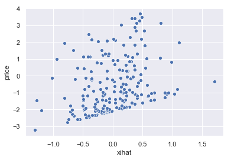

```python
# plot price and unobservables xi
sns.set()
ax = sns.scatterplot('xihat','price',data=nbh_df)
plt.show()
```

### Additional Exercise 2: Counterfactual Prices

Now suppose that the coefficient on school quality in A doubles, while the coefficient associated with log-income and school quality increases by $1.5$

- Calculate the new equilibrium prices, normalizing p1 to be the same in the old and the new equilibrium.
- Create a scatter plot showing how price relates to school quality in both the new and old equilibrium.

```python
# parameter associated with log-income and school quality is the B[1,1]
B_counter = Bhat * np.array([[1.5,1],[1,1]])
print(B_counter)

A_counter = Ahat*2
print(A_counter)
```

```
[[ 1.57727256  0.18173876]
 [ 0.48293352  0.09102158]]
[ 2.01682673 -1.9284225 ]
```

```python
xihat = result.resids
```

```python
p0 = np.zeros(J)
```

```python
# define a new contraction mapping for the prices

# we have to make an assumption that xi are fixed, i.e. unobservable quality is
# uncorrelated with housing price ex-post, i.e., once xi are known, it can't change anymore

# create a contraction function

def p_contract(B,z,x,p,A):
    p1 = np.zeros(J)
    d =  A[0]*x[:,0] + A[1]*p + xihat
    x1= np.column_stack((x[:,0], p, x[:,2]))
    Q = P(B,z,x1,d)
    for j in range(J):
        p1[j] = p[j] - (1/A[1])*(np.log((1/N)*np.sum(Q[:,j])) - np.log(x1[j,2]))
    return p1
```

```python
# check the runtime
start = time.time()
p_contract(B_counter,z,x,p,A_counter)
end = time.time()
print(end - start)
```

```
0.49749279022216797
```

```python
# find the new equilibrium prices
count = 0
maxiter = 200
tol = 1e-6
#p = x[:,1] # using the realized price as the guess of the price.
p = np.zeros(J)+1 #seems like the initial values matter A LOT...
while count < maxiter:
    p2 = p_contract(B_counter,z,x,p,A_counter)
    err = np.max(np.abs(p2-p))
    count = count + 1
    if err >= tol:
        p=p2
        continue
    elif err < tol:
        p_hat = p2
        print(count)
        break
```

```
29
```

```python
# counter factual p scaled
p_star = p_hat*(x[0,1]/p_hat[0])
```

```python
# add counter factual p to the dataframe
nbh_df['counter_p'] = p_star
```

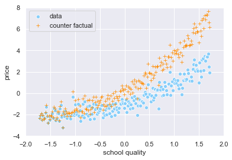

```python
# plot price and unobservables xi
current_palette = sns.color_palette()
sns.set()
ax1 = sns.scatterplot('schqual','price',data = nbh_df, marker = "o", color = "lightskyblue", label = 'data')
ax2 = sns.scatterplot('schqual','counter_p', data = nbh_df, marker="+", color ="darkorange", label = 'counter factual')
plt.xlim((-2, 2))
plt.ylim((-4, 8))
ax1.legend(loc='upper left')
ax2.legend(loc='upper left')
plt.xlabel('school quality')
plt.ylabel('price')
plt.show()
```